# Big Data Analysis

ML Basics and CART

Christoph Kern

## Setup

```r
library(rpart)
library(partykit)
library(caret)
library(pROC)
```

In this exercise, we use a reduced version of the Bank for the Accounts of Companies Harmonized (BACH) data set. “The Bank for the Accounts of Companies Harmonized (BACH) is a free-of-charge database containing the aggregated accounting data of non-financial incorporated enterprises for, so far, 11 European countries.” More information about the BACH data can be found here:

https://www.bach.banque-france.fr/?lang=en

```r
load("BACH.Rda")
```

## Data preparation

As a starting point, we begin with summarizing all variables to get a first impression of the data.

```r
summary(bach)
```

```
    country          year          sector     size       total_assets
 FR     :1449   2012   : 782   C      : 660   0 :2576   Min.   :1.043e+04
 AT     :1436   2013   : 777   F      : 660   1 :2280   1st Qu.:2.547e+06
 DE     :1425   2010   : 773   G      : 660   1a:2292   Median :1.051e+07
 ES     :1367   2008   : 772   H      : 660   1b:2211   Mean   :8.189e+07
 BE     :1363   2011   : 771   Zc     : 660   2 :1888   3rd Qu.:4.508e+07
 IT     :1259   2009   : 769   Mc     : 659             Max.   :3.727e+09
 (Other):2948   (Other):6603   (Other):7288
    turnover         gross_value_added    fixed_assets   current_assets
 Min.   :3.042e+04   Min.   :     7249   Min.   : 5.55   Min.   : 0.23
 1st Qu.:1.826e+06   1st Qu.:   670018   1st Qu.:42.05   1st Qu.: 5.98
 Median :7.038e+06   Median :  2609256   Median :54.76   Median : 9.54
 Mean   :7.466e+07   Mean   : 17230022   Mean   :53.97   Mean   :10.45
 3rd Qu.:3.033e+07   3rd Qu.:  9557686   3rd Qu.:66.86   3rd Qu.:13.42
 Max.   :3.079e+09   Max.   :686887263   Max.   :92.37   Max.   :78.18

  total_equity    total_liabilities  staff_costs    net_profit_or_loss
 Min.   :-74.77   Min.   :  7.92    Min.   : 1.71   Min.   :-345.010
 1st Qu.: 27.13   1st Qu.: 57.95    1st Qu.:14.44   1st Qu.:   1.270
 Median : 33.71   Median : 66.29    Median :21.93   Median :   2.920
 Mean   : 35.22   Mean   : 64.78    Mean   :23.97   Mean   :   3.862
 3rd Qu.: 42.05   3rd Qu.: 72.87    3rd Qu.:31.71   3rd Qu.:   5.060
 Max.   : 92.08   Max.   :174.77    Max.   :95.91   Max.   : 540.600

 return_on_equity
 Min.   :-66737.24
 1st Qu.:     2.86
 Median :     7.35
 Mean   :     1.11
 3rd Qu.:    12.02
 Max.   :   208.59
```

Our machine learning task is to predict whether a corporation experiences a net loss in the year 2015. For this setting, we first compute a binary variable which indicates a loss with “loss” and returns “no_loss” otherwise, based on the variable `bach$net_profit_or_loss`.

```r
bach$D_loss <- ifelse(bach$net_profit_or_loss < 0, "loss", "no_loss")
bach$D_loss <- as.factor(bach$D_loss)
summary(bach$D_loss)
```

```
   loss no_loss
   1549    9698
```

Then we split the data set into a training and test part. Since the data is structured by time, we want to use the year 2015 for the test set and all remaining years for training.

```r
bach_test <- bach[bach$year == "2015",]
bach_train <- bach[bach$year != "2015",]
```

## CART

### Grow and prune tree

In order to build a classification tree with the training data, the `rpart()` function can be used. As the outcome variable, we plug in the new variable we created earlier. If this variable is of class factor, `rpart` adapts to this format and grows a classification tree (instead of a regression tree). Use all variables besides `net_profit_or_loss` and `return_on_equity` as predictors, e.g. via `outcome ~ . - net_profit_or_loss - return_on_equity`.

```r
set.seed(6342)
f_tree <- rpart(D_loss ~ . - net_profit_or_loss - return_on_equity,
                data = bach_train,
                cp = 0.001)
f_tree
```

Next, we want to investigate the Cross-Validation results to find the optimal subtree based on the `rpart` object.

```r
printcp(f_tree)
```

```
Classification tree:
rpart(formula = D_loss ~ . - net_profit_or_loss - return_on_equity,
    data = bach_train, cp = 0.001)

Variables actually used in tree construction:
 [1] country           current_assets    fixed_assets      gross_value_added
 [5] sector            size              staff_costs       total_assets
 [9] total_equity      turnover          year

Root node error: 1483/10541 = 0.14069

n= 10541

          CP nsplit rel error  xerror     xstd
1  0.0549562      0   1.00000 1.00000 0.024072
```

[output cut: 25 more lines]

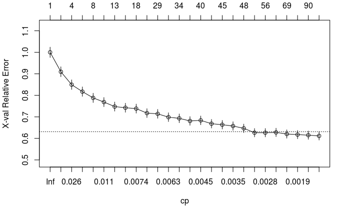

```r
plotcp(f_tree)
```

For pruning, we need the `cp` value of the best subtree. In this code block we prepare tree pruning, e.g. according to the 1-Standard Error rule.

```r
minx <- which.min(f_tree$cptable[,"xerror"])
minxse <- f_tree$cptable[minx,"xerror"] + f_tree$cptable[minx,"xstd"]
minse <- which.min(abs(f_tree$cptable[1:minx,"xerror"] - minxse))
mincp <- f_tree$cptable[minse,"CP"]
mincp
```

```
[1] 0.002360081
```

Now prune the classification tree.

```r
p_tree <- prune(f_tree, cp = mincp)
p_tree
```

### Variable Importance and Plot

We can inspect the tree results by plotting the pruned classification tree. However, be prepared that also pruned trees can be quite large.

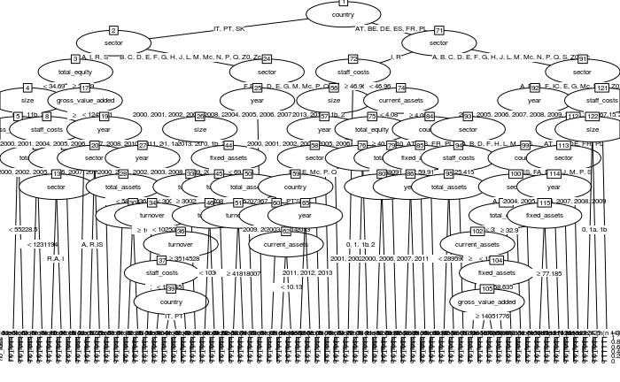

```r
prty_tree <- as.party(p_tree)
plot(prty_tree, gp = gpar(fontsize = 6))
```

The `varImp()` function is useful for listing the importance of each predictor variable for reducing node impurity.

```r
varImp(p_tree)
```

|  | Overall |
| --- | --- |
| country | 345.2730 |
| current_assets | 117.1148 |
| fixed_assets | 158.1512 |
| gross_value_added | 335.7036 |
| sector | 677.2610 |
| size | 333.2577 |
| staff_costs | 471.8964 |
| total_assets | 275.0263 |
| total_equity | 322.1892 |
| total_liabilities | 338.3203 |

[output cut: 2 more lines]

## Prediction

For evaluating performance, we predict the outcome in the test set in two formats. We want to use `predict()` for predicting class membership and also for computing predicted probabilities. Therefore, two prediction objects are generated.

```r
y_class <- predict(p_tree, newdata = bach_test, type = "class")
y_prob <- predict(p_tree, newdata = bach_test, type = "prob")
head(y_prob)
```

```
           loss  no_loss
1365 0.04582096 0.954179
1366 0.04582096 0.954179
1367 0.04582096 0.954179
1368 0.04582096 0.954179
1369 0.04582096 0.954179
1370 0.04582096 0.954179
```

Given predicted class membership, we can use the function `confusionMatrix()` for evaluating our classification model.

```r
confusionMatrix(y_class, bach_test$D_loss, mode = "everything", positive = "loss")
```

```
Confusion Matrix and Statistics

          Reference
Prediction loss no_loss
   loss      31      28
   no_loss   35     612

               Accuracy : 0.9108
                 95% CI : (0.8873, 0.9307)
    No Information Rate : 0.9065
    P-Value [Acc > NIR] : 0.3793

                  Kappa : 0.4472
 Mcnemar's Test P-Value : 0.4497

            Sensitivity : 0.46970
            Specificity : 0.95625
         Pos Pred Value : 0.52542
         Neg Pred Value : 0.94590
              Precision : 0.52542
                 Recall : 0.46970
                     F1 : 0.49600
             Prevalence : 0.09348
         Detection Rate : 0.04391
   Detection Prevalence : 0.08357
      Balanced Accuracy : 0.71297

       'Positive' Class : loss
```

Additionally, ROC curves are helpful for evaluating prediction performance with categorical outcomes. Here we could (e.g.) use the `pROC` package, which has a function called `roc()`.

```r
y_roc <- roc(bach_test$D_loss, y_prob[, 1])
```

On this basis, we can print and plot the resulting roc object.

```r
y_roc
```

```
Call:
roc.default(response = bach_test$D_loss, predictor = y_prob[,     1])

Data: y_prob[, 1] in 66 controls (bach_test$D_loss loss) > 640 cases (bach_test$D_loss no_loss).
Area under the curve: 0.8317
```

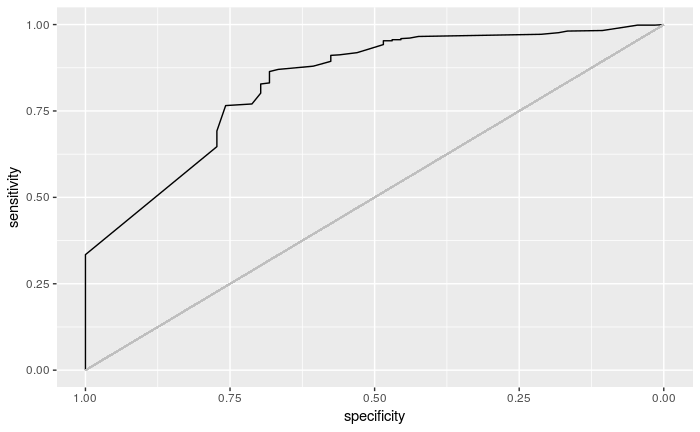

```r
ggroc(y_roc) +
    geom_segment(aes(x = 1, xend = 0, y = 0, yend = 1), color = "grey")
```

Extra task: Try to calculate precision at top 100, i.e. the expected precision when classifying the 100 test observations with the highest risk scores as `loss`. For this, we need to create a new prediction vector. The function `order()` might be helpful here.

```r
yp <- data.frame(y_prob[, 1], bach_test$D_loss)
yp <- yp[order(-yp[, 1]), ]
yp$y_top100 <- "no_loss"
yp[1:100, ]$y_top100 <- "loss"
```

Finally, compute the `precision()` given the new predicted classes.

```r
precision(as.factor(yp$y_top100), yp$bach_test.D_loss, relevant = "loss")
```

```
[1] 0.38
```